# Tier 3 Report - Yellow Perch

Aaron Dain

# 1 Tier 3 Analysis for Mercury in Yellow Perch for the St. Lawrence River (Cornwall/Akwesasne) AOC

## 1.1 Reference Sites

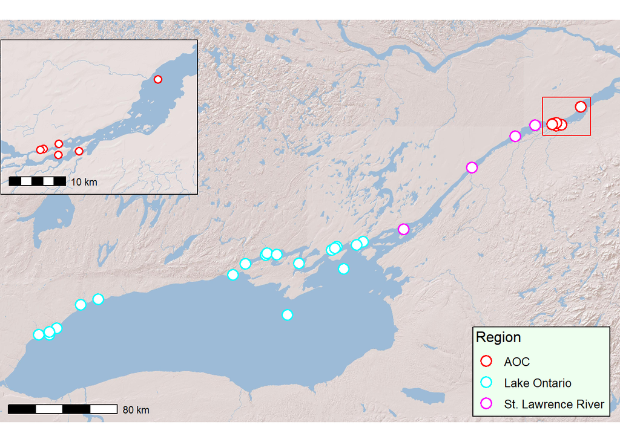

Figure 1.1: Map showing AOC and reference site locations.

The following reference sites were used in the Tier 3 analysis of Mercury in Yellow Perch for the AOC:

#### AOC

- St. Lawrence River - Cornwall Marina
- St. Lawrence River - Cornwall Zone 2
- St. Lawrence River 15 - Cornwall - St Regis Island S
- St. Lawrence River 15 - Cornwall Island South
- St. Lawrence River 15 - Cornwall Waterfront
- St. Lawrence River 15 - Lake St. Francis

#### Lake Ontario

- Lake Ontario - Bath
- Lake Ontario - Breakwater Landing
- Lake Ontario - Cataraqui Bay
- Lake Ontario - Cataraqui River - Anglin Bay
- Lake Ontario - Millhaven
- Lake Ontario 10 - Middle Bay of Quinte
- Lake Ontario 11 - Lower Bay of Quinte/Eastern Lake Ontario
- Lake Ontario 4a - Ashbridges Bay
- Lake Ontario 4a - Humber Bay
- Lake Ontario 4a - Toronto Islands
- Lake Ontario 4a - Toronto Waterfront
- Lake Ontario 6a - Frenchman Bay
- Lake Ontario 6b - Whitby Harbour
- Lake Ontario 8
- Lake Ontario 8 - Presquille Bay
- Lake Ontario 9 - Upper Bay of Quinte
- Lake Ontario 9a - Trenton Nearshore
- Lake Ontario 9b - Bay of Quinte - South Foster Park
- Lake Ontario 9b - Belleville Nearshore

#### St. Lawrence River

- St. Lawrence River - MacDonnel Island
- St. Lawrence River 12 - Lower Thousand Island
- St. Lawrence River 13
- St. Lawrence River 14 - Lake St. Lawrence

### 1.1.1 Note

1 sites with missing coordinates were excluded **from the analysis**. The following sites were affected:

- St. Lawrence River - Cornwall zone 3

## 1.2 Tier 3A: Virtual Advisory for Mercury in Yellow Perch

Virtual advisory values were generated using by modelling the relationship between fish length and contaminant concentration for Yellow Perch and Mercury. For each region, the function fits a log-log linear model (lm(log(Value) ~ log(Length)) to evaluate whether a significant relationship exists (p ≤ 0.05). If so, predicted concentrations are generated across a continuous length range, and then averaged within fixed 5 cm bins. Advisory levels are assigned using MECP-defined contaminant- and population-specific (General/Sensitive) thresholds to the mean predicted concentrations. If no significant relationship is detected, advisory levels are based on the mean concentration of all observations within each bin.

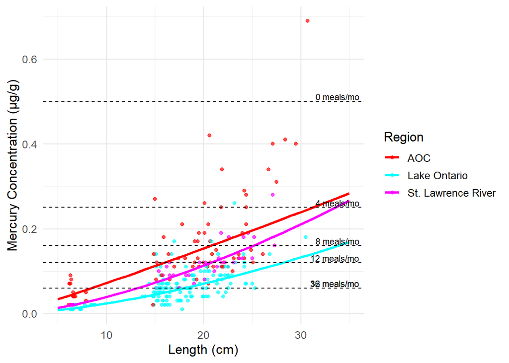

Figure 1.2: Virtual Mercury advisories in Yellow Perch. Predicted concentrations (curve) and observed values (points) by region using power regression model, compared to MECP advisory limits for MERCURY (dashed lines).

### Model Summary by Region

**Lake Ontario**: There is a statistically significant relationship between fish length and contaminant concentration. The power model used was: concentration = 0.000653 × Length<sup>1.562</sup> (R² = 0.596, p = < 0.001).

**AOC**: There is a statistically significant relationship between fish length and contaminant concentration. The power model used was: concentration = 0.00576 × Length<sup>1.095</sup> (R² = 0.546, p = < 0.001).

**St. Lawrence River**: There is a statistically significant relationship between fish length and contaminant concentration. The power model used was: concentration = 0.00114 × Length<sup>1.534</sup> (R² = 0.908, p = < 0.001).

Table 1.1: Virtual advisory levels for Mercury in Yellow Perch across regions. Values represent meals/month recommendations.

| Region | Population | 15-20 | 20-25 | 25-30 | 30-35 | 35-40 |
| --- | --- | --- | --- | --- | --- | --- |
| AOC | General | 32 | 16 | 16 | 16 | 16 |
| AOC | Sensitive | 12 | 8 | 8 | 4 | 4 |
| Lake Ontario | General | 32 | 32 | 32 | 32 | 16 |
| Lake Ontario | Sensitive | 32 | 16 | 16 | 12 | 8 |
| St. Lawrence River | General | 32 | 32 | 16 | 16 | 16 |
| St. Lawrence River | Sensitive | 16 | 12 | 8 | 8 | 4 |

## 1.3 Tier 3B: Comparison of contaminant concentrations in Yellow Perch in AOC to reference

To assess differences in fish contamination between the AOC and reference sites, contaminant–length relationships were modeled using Generalized Additive Models (GAMs), allowing for non-linear associations. For each priority contaminant and indicator species, we first tested whether the shape of the concentration–length relationship differed significantly between AOC and reference fish. Where models supported statistically similar trends (non-significant interaction), we compared size-adjusted contaminant levels using estimated marginal means. Where shapes differed significantly, contaminant concentration values were compared by GAM-predicted values at standardized lengths (e.g., 45cm) commonly consumed for each fish species. A threshold of α = 0.05 was used to evaluate statistical significance throughout.

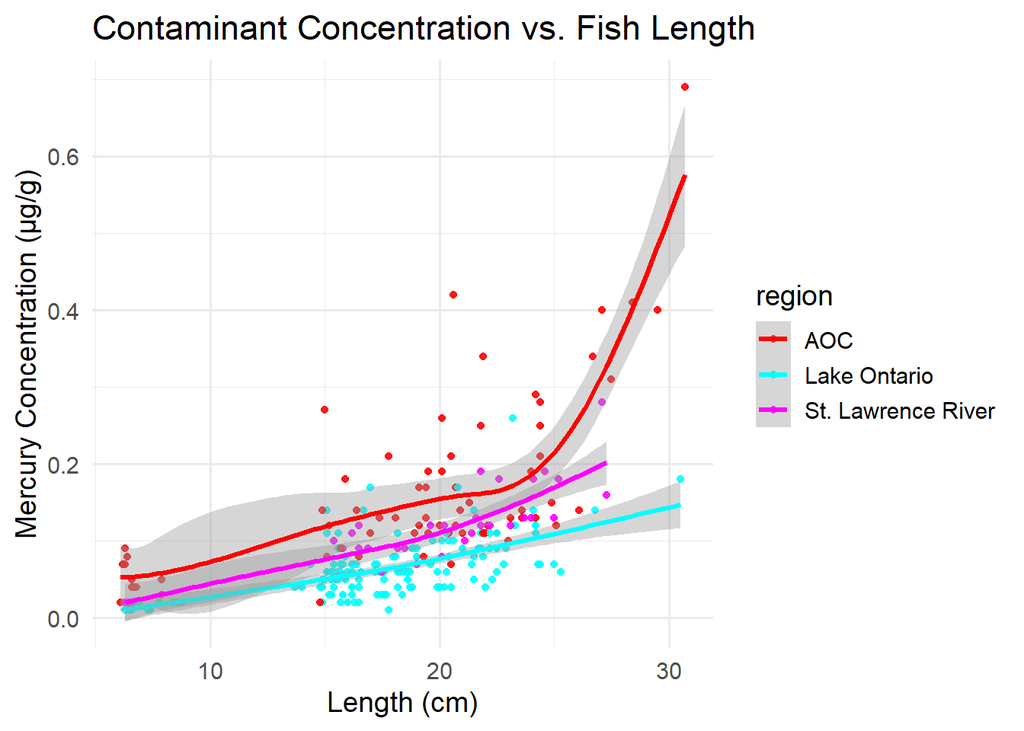

Figure 1.3: Mercury concentration in Yellow Perch by length in the AOC compared to reference sites.

Generalized Additive Models (GAMs) were used to model the relationship between fish length and mercury concentrations for Yellow Perch in the AOC and reference sites (Lake Ontario, St. Lawrence River). The length-contaminant relationship differed significantly between sites (interaction test p = 1.56e-10). Model-predicted concentrations were compared at a standardized fish length of 20 cm. At this length, the predicted mercury concentration was 0.16 µg/g (95% CI: 0.14–0.18) in the AOC. Predicted concentrations in reference site(s) were: Lake Ontario: 0.08 µg/g (95% CI: 0.07–0.09); St. Lawrence River: 0.12 µg/g (95% CI: 0.1–0.13).

## 1.4 Tier 3C: Temporal Trends

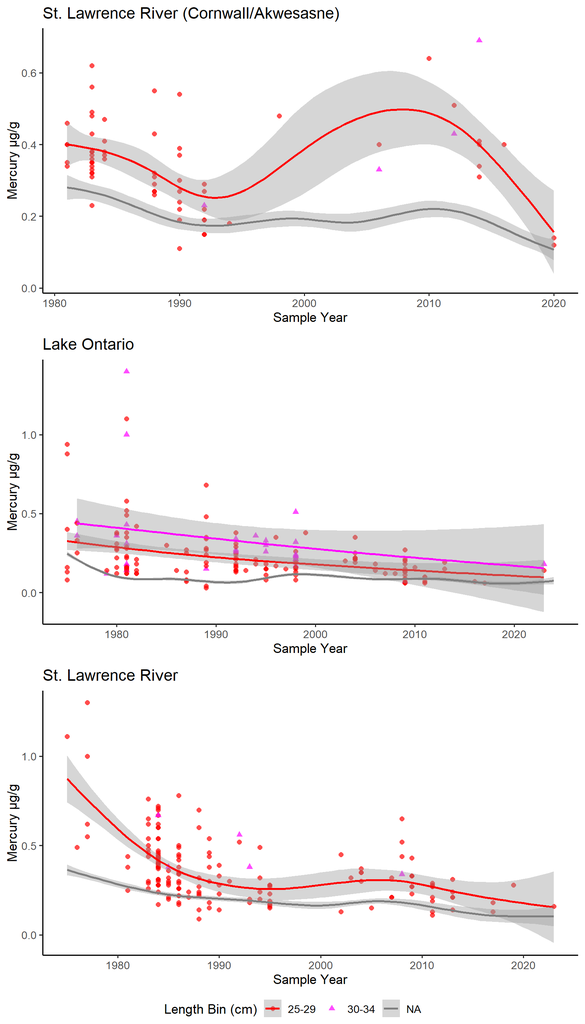